# Trabajo Práctico Nro.2

Análisis Inteligente de Datos

Conde, M. Cecilia

07/07/2024

# General

```r
knitr::opts_chunk$set(echo = TRUE)
# indica desde dónde instalar paquetes
options(repos = c(CRAN = "http://cran.rstudio.com"))
require("knitr")
# Seteo de directorio de trabajo
setwd("C:/Users/mconde/Documents/AID/TP2")
# Muestra directorio de trabajo
getwd()
```

```
## [1] "C:/Users/mconde/Documents/AID/TP2"
```

```r
#librerías
library(plotly)
library(MASS)
library(car)
library(tidyverse)
library(dplyr)
library(reshape2)
library(kableExtra)
library(readxl)
library(stats)
library(BSDA)
library(ggplot2)
library(fastmap)
library(latex2exp)
library(vip) #importancia de las variables al modelos
library(mvShapiroTest) #hacer shapiro en analisis de discriminante
library(tidymodels)
library(devtools)
library(klaR)
library(ggord)
library(mlr)
library(GGally)
library(heplots) #varianza multivariada
```

# 1. Armar base de datos

## 1.1 Lectura de datos

- Para este ejercicio práctico se utilizo el provisto por los docentes de AID. Este dataset tiene además de las variables original, algunas variables categorias armadas en función de la variable descripción y títulos. Asimismo se utiliza el archivo “barrios.xlsx”, disponible en el portal de *datos abiertos del Gobierno de la Ciudad de Buenos Aires* para generar las variables Comuna y Zona.

```r
#Leer datos
entrenamiento <-read_excel("datos_tp2.xlsx")
barrio<-read_excel("barrios.xlsx") #barrios portal datos abiertos CABA
```

## 1.2 Filtro de registros y atributos

La base de datos para incluir solo aquellos donde:

- l1 - Nivel administrativo 1: Argentina.
- l2 - Nivel administrativo 2:Capital Federal.
- l3 -Nivel administrativos 3: **Elimino los registros que tengan NAN**
- property_type - Tipo de propiedad: PH.
- operation_type - Tipo de operación: Venta.
- Omita las columnas: start_date, end_date, created_on, title y description.

```r
#filtro de datos
entrenamiento_sin_columnas <- entrenamiento %>%select(-start_date,-end_date,-created_on, -title,-description)

datos <- subset(entrenamiento_sin_columnas, l2 == "Capital Federal" & property_type  == "PH" & operation_type == "Venta" & !is.na(l3))
```

## 1.3 Generacion de Nuevas Varibles “Comuna” y “Zona”

- En el archvio barrio se agrupa las comunas en zonas en función de la siguiente información: Norte A = comunas 12-15, Este B = comunas 1-3, Sur C = comunas 4, 8, 9 y Oeste D = comunas 5-7, 10,11.
- Luego se une este archivo con el archivo que contiene las propiedas a traves de la columna barrio.

```r
barrio$comuna1<- barrio$COMUNA/100000000000
barrio$zona <- NA  # Inicializamos la columna zona con NA
# Asignamos los valores correspondientes según las condiciones
barrio$zona[barrio$comuna1 %in% c(12, 13, 14, 15)] <- "Norte A"
barrio$zona[barrio$comuna1 %in% c(1, 2, 3)] <- "Este B"
barrio$zona[barrio$comuna1 %in% c(4, 8, 9)] <- "Sur C"
barrio$zona[barrio$comuna1 %in% c(5, 6, 7, 10, 11)] <- "Oeste D"
barrio <- barrio[!is.na(barrio$comuna1), ]
barrio<-barrio[c("BARRIO","comuna1", "zona")]
head(barrio)
```

| BARRIO | comuna1 | zona |
| --- | --- | --- |
| CHACARITA | 15 | Norte A |
| PATERNAL | 15 | Norte A |
| VILLA CRESPO | 15 | Norte A |
| VILLA DEL PARQUE | 11 | Oeste D |
| ALMAGRO | 5 | Oeste D |
| CABALLITO | 6 | Oeste D |

- Se unen los archivo a través de la columna Barrio y l3

```r
# Realiza un join
datos$l3 <- toupper(datos$l3)
datos_total <- merge(datos, barrio, by.x = "l3", by.y = "BARRIO")
head(datos_total)
```

|  | l3 | id | ad_type | lat | lon | l1 | l2 | l4 | l5 | l6 | rooms | bedrooms | bathrooms | surface_total | surface_covered | currency | price_period | property_type | operation_type | price | luminoso | reciclado | expensas | espectacular | quincho | terraza | escalera | galeria | comuna1 | … |
| --- | --- | --- | --- | --- | --- | --- | --- | --- | --- | --- | --- | --- | --- | --- | --- | --- | --- | --- | --- | --- | --- | --- | --- | --- | --- | --- | --- | --- | --- | --- |
| 1 | ALMAGRO | 25198 | Propiedad | -58.41403 | -34.59904 | Argentina | Capital Federal | NA | NA | NA | 3 | 2 | 1 | 60 | 60 | USD | NA | PH | Venta | 176550 | 0 | 0 | 1 | 0 | 0 | 0 | 0 | 0 | 5 | … |
| 2 | ALMAGRO | 29473 | Propiedad | -58.42049 | -34.59952 | Argentina | Capital Federal | NA | NA | NA | 5 | NA | 2 | NA | 85 | USD | Mensual | PH | Venta | 145000 | 0 | 0 | 1 | 0 | 0 | 0 | 0 | 0 | 5 | … |
| 3 | ALMAGRO | 37375 | Propiedad | -58.43306 | -34.60099 | Argentina | Capital Federal | NA | NA | NA | 3 | 2 | 1 | 70 | 70 | USD | Mensual | PH | Venta | 159500 | 0 | 0 | 1 | 0 | 0 | 1 | 1 | 0 | 5 | … |
| 4 | ALMAGRO | 12065 | Propiedad | -58.43552 | -34.61055 | Argentina | Capital Federal | NA | NA | NA | 3 | NA | 1 | 90 | NA | USD | Mensual | PH | Venta | 237000 | 0 | 0 | 0 | 0 | 0 | 0 | 0 | 0 | 5 | … |
| 5 | ALMAGRO | 853862 | Propiedad | -58.43173 | -34.60863 | Argentina | Capital Federal | NA | NA | NA | 3 | 2 | 1 | 61 | 46 | USD | NA | PH | Venta | 125000 | 0 | 0 | 0 | 0 | 0 | 0 | 0 | 0 | 5 | … |
| 6 | ALMAGRO | 29474 | Propiedad | -58.41473 | -34.60574 | Argentina | Capital Federal | NA | NA | NA | 5 | 4 | 2 | 107 | 107 | USD | NA | PH | Venta | 200000 | 0 | 0 | 1 | 0 | 0 | 0 | 0 | 0 | 5 | … |

## 1.4 Generación de Muestra Aleatoria

- Muestra aleatoria de tamaño n = 500 utilizando como semilla los últimos tres dígitos de mi DNI: 28233**214.**

```r
#muestra de datos con seed 214
set.seed(214)
df <-sample_n(datos_total, size=500, replace=FALSE)
```

# 2.Analisis Variables Cuantitativas según comuna de CABA:

```r
#datos duplicados
any(duplicated(df))
```

```
## [1] FALSE
```

```r
sum(is.na(df))# para saber cuantos na hay en la base de datos
```

```
## [1] 2109
```

```r
#prices nulos
any(is.na(df$price))
```

```
## [1] TRUE
```

```r
# Crear una función para eliminar outliers de una columna
mark_outliers_as_na <- function(x) {
  Q1 <- quantile(x, 0.25, na.rm = TRUE)
  Q3 <- quantile(x, 0.75, na.rm = TRUE)
  IQR <- Q3 - Q1
  lower_bound <- Q1 - 1.5 * IQR
  upper_bound <- Q3 + 1.5 * IQR
  x[x < lower_bound | x > upper_bound] <- NA
  return(x)
}
# Especificar las columnas a las que se debe aplicar la función
columns_to_modify <- c("surface_total", "surface_covered", "price", "rooms")
# Aplicar la función a las columnas especificadas del dataframe, agrupado por comuna
datos_marked <- df %>%
  group_by(comuna1) %>%
  mutate(across(all_of(columns_to_modify), mark_outliers_as_na)) %>%
  ungroup() # Desagrupar al finalizar
```

```r
#prices nulos
any(is.na(datos_marked$price))
```

```
## [1] TRUE
```

```r
# Filtrar el dataframe para eliminar filas con valores NA en precio
df <- subset(datos_marked, !is.na(price))
# Filtrar el dataframe para eliminar filas con NA en supericie total y superficie cubierta, el resto voy a imputar
df <-subset(df,!is.na(surface_covered)& !is.na(!surface_total))
```

## 2.1. Imputar datos faltantes

### 2.1.1 Imputar valores de ‘bedrooms’ y ‘bathrooms’

- Se asume que la cantidad de ambientes es habitaciones+1 y la cantidad de habitaciones es ambientes-1

```r
# Imputar valores de 'bedrooms' y 'rooms'
df <- df %>%
  mutate(bedrooms = ifelse(is.na(bedrooms), rooms - 1, bedrooms),
         rooms = ifelse(is.na(rooms), bedrooms + 1, rooms))
```

### 2.1.2 Imputar otros valores faltantes

- Se imputan los datos faltantes de las otras variables númericas con la mediana de cada una de ellas, para agilizar el análisis.

```r
df<- df %>% mutate_if(is.numeric, ~ ifelse(is.na(.), median(., na.rm = TRUE), .))
colSums(is.na(df))
```

```
##              l3              id         ad_type             lat             lon
##               0               0               0               0               0
##              l1              l2              l4              l5              l6
##               0               0             369             379             379
##           rooms        bedrooms       bathrooms   surface_total surface_covered
##               0               0               0               0               0
##        currency    price_period   property_type  operation_type           price
##               0             227               0               0               0
##        luminoso       reciclado        expensas    espectacular         quincho
##               0               0               0               0               0
##         terraza        escalera         galeria         comuna1            zona
##               0               0               0               0               0
```

```r
#Luego de la limpieza se realiza las dimensiones
dim(df)
```

```
## [1] 379  30
```

## 2.2. Resumen

Con todos los datos imputados, se procede a calcular las medidas de resumen para cada variable por comuna.

Realice un descriptivo de las variables cuantitativas (numéricas) según comuna de CABA. Presente la información en forma tabular y conteniendo las siguientes medidas descriptivas: Cantidad de datos, mínimo, máximo, media, varianza y desviación estándar.

- Con todos los datos imputados, se procede a **calcular las medidas finales de resumen** para cada variable por comuna.

```r
# Función para calcular estadísticas descriptivas
resumen_descriptivo <- function(df) {
  describe(df)
}

# Agrupar por comuna y aplicar la función de resumen descriptivo
resumen_por_comuna <- df %>%
  select(-lat,-lon,-luminoso,-reciclado,-expensas,-espectacular,-quincho,-terraza, -escalera, -galeria,)%>% #elimina estas columnas del analisis
  select_if(is.numeric) %>% #numerica continua
  group_by(comuna1) %>% #agrupa por comuna
  summarise(across(where(is.numeric),
                   list(count = ~length(.),
                        min = ~min(., na.rm = TRUE),
                        max = ~max(., na.rm = TRUE),
                        mean = ~mean(., na.rm = TRUE),
                        var = ~var(., na.rm = TRUE),
                        sd = ~sd(., na.rm = TRUE)),
                   .names = "{col}_{fn}"))
head(resumen_por_comuna)
```

| comuna1 | id_count | id_min | id_max | id_mean | id_var | id_sd | rooms_count | rooms_min | rooms_max | rooms_mean | rooms_var | rooms_sd | bedrooms_count | bedrooms_min | bedrooms_max | bedrooms_mean | bedrooms_var | bedrooms_sd | bathrooms_count | bathrooms_min | bathrooms_max | bathrooms_mean | bathrooms_var | bathrooms_sd | surface_total_count | surface_total_min | surface_total_max | surface_total_mean | surface_total_var | … |
| --- | --- | --- | --- | --- | --- | --- | --- | --- | --- | --- | --- | --- | --- | --- | --- | --- | --- | --- | --- | --- | --- | --- | --- | --- | --- | --- | --- | --- | --- | --- |
| 1 | 14 | 28326 | 986212 | 355641.4 | 159408750702 | 399260.3 | 14 | 2 | 5 | 2.928571 | 0.5329670 | 0.7300459 | 14 | 1 | 4 | 1.928571 | 0.532967 | 0.7300459 | 14 | 1 | 3 | 1.428571 | 0.5714286 | 0.7559289 | 14 | 30 | 173 | 78.28571 | 2124.066 | … |
| 2 | 3 | 14177 | 582452 | 211336.7 | 103429549380 | 321604.6 | 3 | 2 | 5 | 3.333333 | 2.3333333 | 1.5275252 | 3 | 1 | 4 | 2.333333 | 2.333333 | 1.5275252 | 3 | 1 | 1 | 1.000000 | 0.0000000 | 0.0000000 | 3 | 66 | 140 | 94.66667 | 1577.333 | … |
| 3 | 21 | 3994 | 964875 | 212033.8 | 96838842490 | 311189.4 | 21 | 2 | 5 | 3.095238 | 0.3904762 | 0.6248809 | 21 | 1 | 4 | 2.000000 | 0.500000 | 0.7071068 | 21 | 1 | 2 | 1.428571 | 0.2571429 | 0.5070926 | 21 | 20 | 130 | 79.76190 | 1144.890 | … |
| 4 | 12 | 1736 | 787056 | 163652.8 | 62856790158 | 250712.6 | 12 | 2 | 7 | 3.500000 | 1.7272727 | 1.3142575 | 12 | 1 | 6 | 2.500000 | 1.727273 | 1.3142575 | 12 | 1 | 3 | 1.250000 | 0.3863636 | 0.6215816 | 12 | 45 | 280 | 120.16667 | 4635.242 | … |
| 5 | 42 | 2912 | 984695 | 153983.3 | 61336019300 | 247661.1 | 42 | 2 | 8 | 3.476190 | 1.3286876 | 1.1526871 | 42 | 1 | 7 | 2.476190 | 1.328688 | 1.1526871 | 42 | 1 | 4 | 1.523810 | 0.5481998 | 0.7404051 | 42 | 34 | 234 | 100.61905 | 2373.510 | … |
| 6 | 17 | 5999 | 375898 | 121135.1 | 20847699442 | 144387.3 | 17 | 2 | 5 | 3.235294 | 0.9411765 | 0.9701425 | 17 | 1 | 4 | 2.176471 | 1.029412 | 1.0145993 | 17 | 1 | 2 | 1.294118 | 0.2205882 | 0.4696682 | 17 | 37 | 153 | 98.00000 | 1397.750 | … |

# 3. Diferencia de Medias

Seleccione una variable cuantitativa. Elija dos comunas, para estimar la diferencia de medias con un nivel de confianza del 95%. Realice las pruebas adecuadas para verificar los supuestos teóricos.

- Se desea conocer el intervalo de confianza del 95% de la diferencia de medias entre los precios de los PH entre la comuna 12 y 14, para ello se selecciona una **muestra aleatoria** de **20** PH para cada una de las comunas.
- Comunas 12 (Saavedra, Coghlan, Villa Urquiza y Villa Pueyrredón) y las comunas 14 (Palermo).

```r
# Tamaño de la muestra
set.seed(214)
n=20
comuna1 <- 12
comuna2 <- 14

# Tomar muestras aleatorias para cada comuna
muestra_comuna1 <- sample(df$price[df$comuna1 == comuna1], n, replace=FALSE)
muestra_comuna2 <- sample(df$price[df$comuna1 == comuna2], n, replace=FALSE)

muestra_comuna1
```

```
##  [1] 145000 101310 167000 348000 250000 270000 240000 189000 203000 320000
## [11] 175000 135000 139000 171000 135000 155000 285000 155000 245000 170000
```

```r
muestra_comuna2
```

```
##  [1] 239000 278000 260000  80000 164000 375000 320000 145000 129000 265500
## [11] 144900 230000 125000 135000 239000 295000 278000 230000 164000 243000
```

```r
# Dataframe con las muestras
data <- data.frame(
  value = c(muestra_comuna1, muestra_comuna2),
  group = factor(rep(c("comuna1", "comuna2"), c(length(muestra_comuna1), length(muestra_comuna2))))
)
```

## 3.1 Análisis Exploratorio de Datos

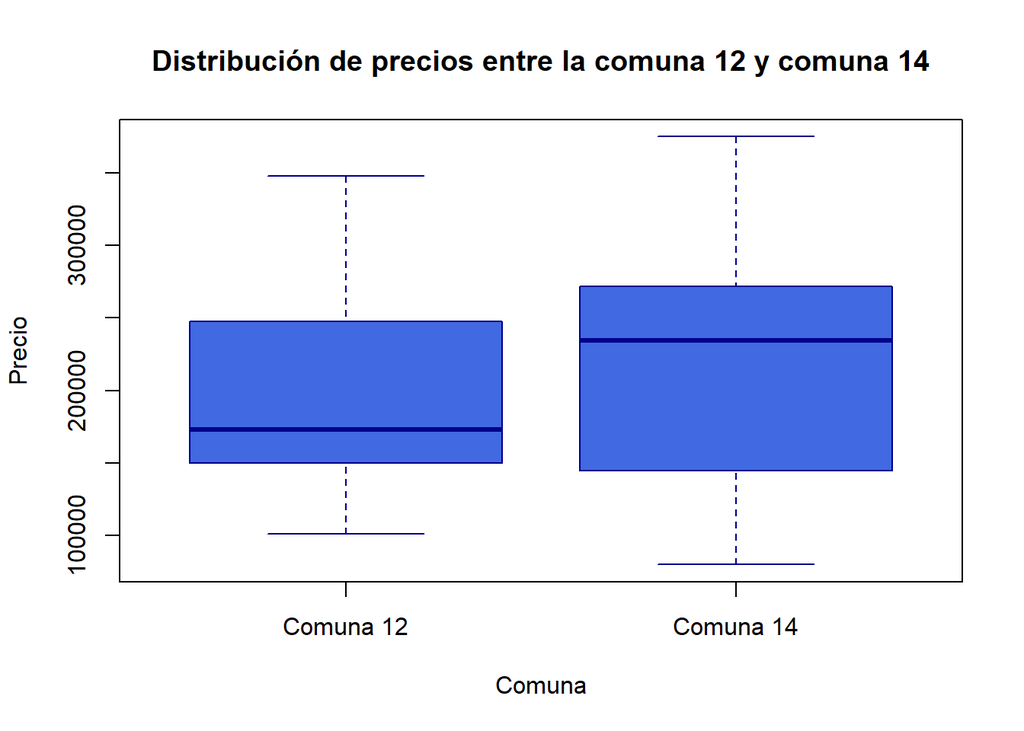

```r
boxplot(value~group,data=data,xlab="Comuna",ylab="Precio",col="royalblue",border="darkblue", main= "Distribución de precios entre la comuna 12 y comuna 14",names = FALSE) # Desactivar las etiquetas de nombres automáticas

# Agregar etiquetas personalizadas en el eje x
axis(1, at = 1:2, labels = c("Comuna 12", "Comuna 14"))
```

## 3.2 Supuestos

### 3.2.1 Normalidad

- Se prueba normalidad a través de qqplot y del test de Shapiro-Wilk.

### Hipótesis de Normalidad

- Hipotesis Nula(Ho): Los datos siguen una distribución normal.
- Hipotesis Alternitva (H1) : Los datos siguen una distribución normal

```r
# Prueba de normalidad - Shapiro-Wilk
shapiro.test(muestra_comuna1)
```

```
##
##  Shapiro-Wilk normality test
##
## data:  muestra_comuna1
## W = 0.9239, p-value = 0.1178
```

```r
shapiro.test(muestra_comuna2)
```

```
##
##  Shapiro-Wilk normality test
##
## data:  muestra_comuna2
## W = 0.95822, p-value = 0.509
```

```r
par(mfrow = c(1, 2))
# Ajustar los tamaños de las etiquetas y títulos usando par
par(cex.lab = 0.5, cex.main = 0.8, cex.axis = 0.5)
qqPlot(muestra_comuna1,
       main = "QQ Plot de Muestra de Comuna 12",
       xlab = "Cuantiles Teóricos",
       ylab = "Cuantiles Muestra",
       col = "blue",
       pch = 19,
       grid = TRUE)
```

```
## [1]  4 10
```

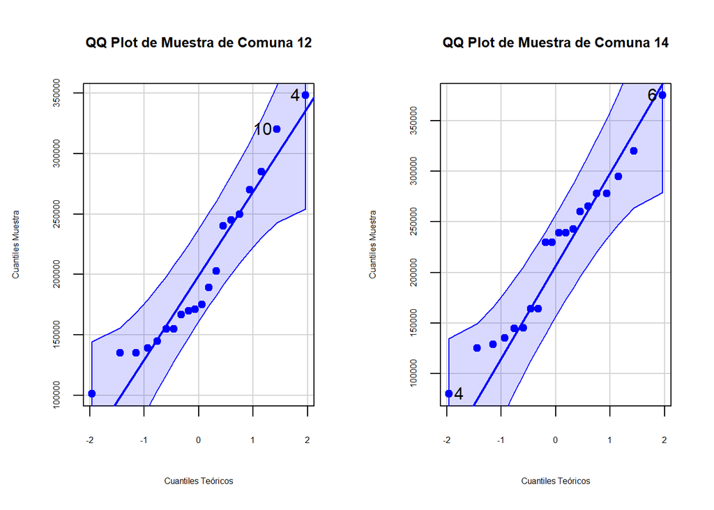

```
## [1] 6 4
```

```r
qqPlot(muestra_comuna2,
       main = "QQ Plot de Muestra de Comuna 14",
       xlab = "Cuantiles Teóricos",
       ylab = "Cuantiles Muestra",
       col = "blue",
       pch = 19,
       grid = TRUE)
```

- No se rechaza la hipotesis nula. Hay evidencia suficiente que los datos siguen una distribución normal. *Se cumple el supuesto de normalidad*.

### 3.2.2 Homocedasticidad

- Se realizan el test de Levene para analizar la homogenidad varianzas.

### Hipótesis sobre las varianzas poblacionales

- **Hipótesis Nula (H0)**: Las varianzas son iguales.
- **Hipótesis Alternativa (H1)**: Las varianzas son diferentes

```r
# test de Levene
leveneTest(value ~ group, data = data)
```

|  | Df | F value | Pr(>F) |
| --- | --- | --- | --- |
| group | 1 | 0.4065466 | 0.5275511 |
|  | 38 | NA | NA |

- El test de Levene arroja un p-valor de 0.5276, mayor al 𝝰 (valor de significancia) establecido. Por lo cual no se rechaza la hipótesis que la varianzas son homogeneas. *Se cumple el supuesto de homogeneidad de varianzas*

### 3.2.2 Independencia de las observaciones

Viene determinada principalmente por el diseño del estudio. Seleccionar muestras de forma aleatoria es una estrategia que permite que las observaciones sean independientes entre sí.

## 3.3 Intervalo de Confianza del 95%

- Dado que se cumplen con los supuestos, se procede a calcular el intervalo de confianza.

```r
# Intervalo de confianza del 95% para la diferencia de medias
resultado <- t.test(muestra_comuna1, muestra_comuna2,
                    mu = 0,
                    alternative = "two.sided",
                    var.equal = TRUE,  # Asumiendo varianzas iguales
                    conf.level = 0.95)

print(resultado$conf.int)
```

```
## [1] -63509.85  29400.85
## attr(,"conf.level")
## [1] 0.95
```

- Con un intervalo de confianza del 95%, la diferencia entre las medias de los precios de los PH en las comunas 12 y 14 se encuentra entre **-63509.85 y 29400.85 $**. Dado que este intervalo incluye el valor cero, podemos concluir que no existe una diferencia estadísticamente significativa en el precio medio de los PH entre ambas comunas.

# 4. Test de Hipótesis de Diferencia de Medias

Según el resultado obtenido en el punto 3.- realice un test de hipótesis apropiado para determinar la diferencia de medias de la variable en estudio. Trabaje con una significación del 5%. Presente el planteo de hipótesis adecuado, la resolución y la decisión a tomar.

## 4.1 Planteo de Hipótesis:

$$\begin{aligned}
&\text{Hipótesis Nula (Ho)}: \mu_{12} - \mu_{14} = 0 \\
&\text{Hipótesis Alternativa (H1)}: \mu_{12} - \mu_{14} \neq 0 \\
\end{aligned}$$

- La hipotesis nula plantea que no hay diferencia en el precio promedio entre los PH de la comuna 12 y los ph de la comuna 14.
- Se realiza un test de diferencia de medias con t-test.

```r
# Intervalo de confianza del 95% para la diferencia de medias
resultado <- t.test(muestra_comuna1, muestra_comuna2,
                    mu = 0,
                    alternative = "two.sided",
                    var.equal = TRUE,  # Asumiendo varianzas iguales
                    conf.level = 0.95)

print(resultado)
```

```
##
##  Two Sample t-test
##
## data:  muestra_comuna1 and muestra_comuna2
## t = -0.74319, df = 38, p-value = 0.4619
## alternative hypothesis: true difference in means is not equal to 0
## 95 percent confidence interval:
##  -63509.85  29400.85
## sample estimates:
## mean of x mean of y
##  199915.5  216970.0
```

- Asumiendo un nivel de significa de 5%, **NO se rechaza la hipotesis nula**. No hay evidencia suficiente para decir que el precio de los PH de la comuna 12 y 14 sean diferentes.

# 5. Prueba de Mann

Elija dos comunas donde no se cumplan los supuestos necesarios para hacer diferencia de medias y aplique la prueba de Mann Whitney con una significación del 5%.

- Se desea conocer si hay diferencia entre la superficie cubierta dentro de las comunas de CABA, por ello se seleccionaron al azar 8 PH de la comuna 7 (Flores y Parque Chacabuco) y 8 ph de la comuna 4 (Parque Patricios, Barracas, Nueva Pompeya y Boca).

```r
# Tamaño de la muestra
set.seed(214)
n=8
comuna1 <- 7
comuna2 <- 4
# Tomar muestras aleatorias para cada comuna
muestra_comuna1 <- sample(df$surface_covered[df$comuna1 == comuna1], n, replace=FALSE)
muestra_comuna2 <- sample(df$surface_covered[df$comuna1 == comuna2], n, replace=FALSE)

muestra_comuna1
```

```
## [1]  59  62 140  45  53  73  83  49
```

```r
muestra_comuna2
```

```
## [1]  46 102 143  77 280  49  52 120
```

```r
# Dataframe con las muestras
data <- data.frame(
  value = c(muestra_comuna1, muestra_comuna2),
  group = factor(rep(c("comuna7", "comuna4"), c(length(muestra_comuna1), length(muestra_comuna2))))
)
```

## 5.1 Análisis Exploratorio de Datos

[figure not shown]

```r
boxplot(value~group,data=data,xlab="Comuna",ylab="Precio",col="lightgreen",border="darkgreen", main= "Distribución de superficie cubierta entre las comunas 7 y 4",names = FALSE) # Desactivar las etiquetas de nombres automáticas

# Agregar etiquetas personalizadas en el eje x
axis(1, at = 1:2, labels = c("Comuna 7", "Comuna 4"))
```

## 5.2 Supuestos

### 5.2.1 Normalidad

- Se prueba normalidad a través de qqplot y el test de Shapiro-Wilk.

### Hipótesis de Normalidad

- Hipotesis Nula(Ho): Los datos siguen una distribución normal.
- Hipotesis Alternitva (H1) : Los datos siguen una distribución normal.

```r
shapiro.test(muestra_comuna1)
```

```
##
##  Shapiro-Wilk normality test
##
## data:  muestra_comuna1
## W = 0.78153, p-value = 0.0181
```

```r
shapiro.test(muestra_comuna2)
```

```
##
##  Shapiro-Wilk normality test
##
## data:  muestra_comuna2
## W = 0.80387, p-value = 0.03149
```

```r
par(mfrow = c(1, 2))
# Ajustar los tamaños de las etiquetas y títulos usando par
par(cex.lab = 0.5, cex.main = 0.8, cex.axis = 0.5)
qqPlot(muestra_comuna1,
       main = "QQ Plot de Muestra de Comuna 10",
       xlab = "Cuantiles Teóricos",
       ylab = "Cuantiles Muestra",
       col = "blue",
       pch = 19,
       grid = TRUE)
```

```
## [1] 3 4
```

[figure not shown]

```
## [1] 5 1
```

```r
qqPlot(muestra_comuna2,
       main = "QQ Plot de Muestra de Comuna 4",
       xlab = "Cuantiles Teóricos",
       ylab = "Cuantiles Muestra",
       col = "blue",
       pch = 19,
       grid = TRUE)
```

- Se rechaza la hipotesis nula de normalidad. *No se cumple el supuesto de normalidad.*

### 5.2.2. Homocedasticidad

- Se realiza el test de Levene para analizar la homogenidad varianzas.

```r
# test de Levene
leveneTest(value ~ group, data = data)
```

|  | Df | F value | Pr(>F) |
| --- | --- | --- | --- |
| group | 1 | 2.285204 | 0.1528535 |
|  | 14 | NA | NA |

- Con p-valor de 0.1529, mayor al nivel de significancia (0.05), no se rechaza la hipotesis que la varianzas son homogeneas. *Se cumple el supuesto de homocedasticidad*

## 5.3 Test de Mann

- Dado que no se cumple el supuesto de normalidad, se procede hacer un análisis no parametrico, Test de Mann.

### Hipótesis

$$\begin{aligned}
&\text{Hipótesis Nula (Ho)}: \theta_A = \theta_C \\
&\text{Hipótesis Alternativa (H1)}: \theta_A \neq \theta_C
\end{aligned}$$

```r
# Realizar la prueba de Mann-Whitney
resultado_mann_whitney <- wilcox.test(muestra_comuna1, muestra_comuna2, alternative = "two.sided")
resultado_mann_whitney
```

```
##
##  Wilcoxon rank sum test with continuity correction
##
## data:  muestra_comuna1 and muestra_comuna2
## W = 23.5, p-value = 0.4005
## alternative hypothesis: true location shift is not equal to 0
```

- El p-value >= 0.05, por lo tanto, no se rechaza la hipótesis nula. No hay suficiente evidencia para concluir que la superficie cubierta de los PH difiere entre las comunas 7 y 4.

# 6. Anova

Seleccione 4 comunas y tome muestras adecuadas para realizar el análisis de la varianza para una variable cuantitativa elegida a su criterio. Verifique los supuestos necesarios. Trabaje con una significación del 5%. En caso de que no se verifiquen los supuestos necesarios aplique una prueba alternativa.

- Se desea determinar si existe una diferencia en el precio medio de los PH en la Zona Norte A. Para ello**, se seleccionaron aleatoriamente 15 PH** de cada una de las Comunas 12, 13, 14 y 15, todas pertenecientes a dicha zona.

```r
# Tamaño de la muestra
set.seed(214)
n=15
comuna1 <- 12
comuna2 <- 13
comuna3 <- 14
comuna4 <- 15
#muestras aleatorias para cada comuna
muestra_comuna1 <- sample(df$price[df$comuna1 == comuna1], n, replace=FALSE)
muestra_comuna2 <- sample(df$price[df$comuna1 == comuna2], n, replace=FALSE)
muestra_comuna3 <- sample(df$price[df$comuna1 == comuna3], n, replace=FALSE)
muestra_comuna4 <- sample(df$price[df$comuna1 == comuna4], n, replace=FALSE)

# Dataframe con las muestras
data <- data.frame(
  value = c(muestra_comuna1, muestra_comuna2, muestra_comuna3, muestra_comuna4),
  group = factor(rep(c("comuna 12", "comuna 13", "comuna 14", "comuna 15"),
                     c(length(muestra_comuna1),length(muestra_comuna2),length(muestra_comuna3),length(muestra_comuna4))))
)
```

## 6.1 Análisis Exploratorio de Datos

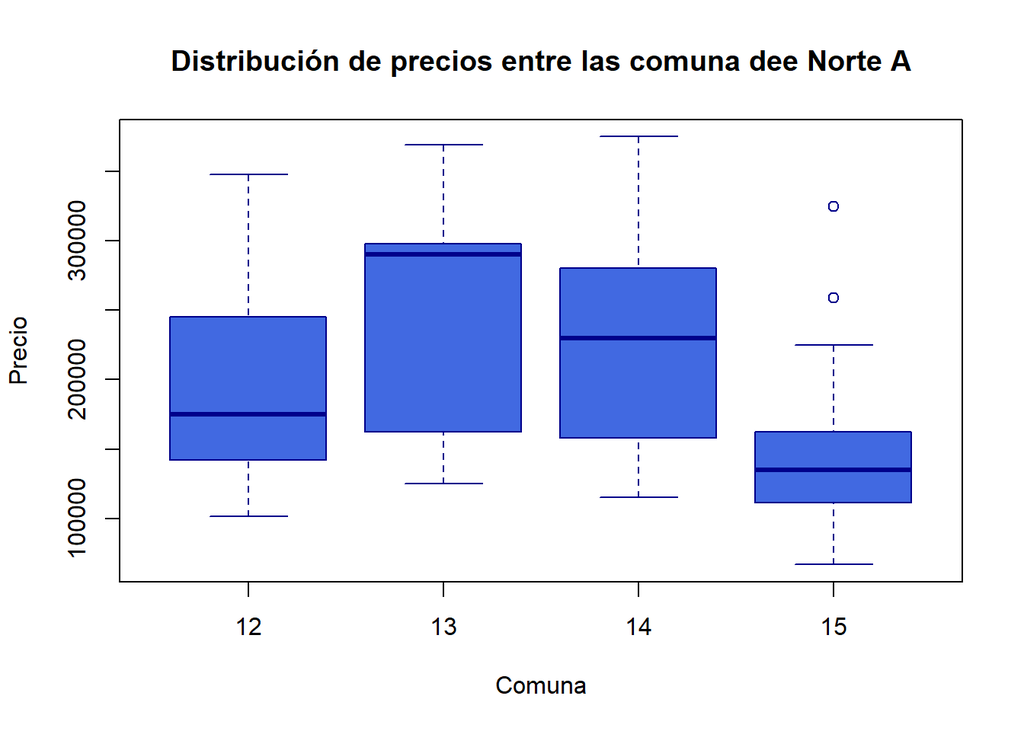

```r
boxplot(value~group,data=data,xlab="Comuna",ylab="Precio",col="royalblue",border="darkblue", main= "Distribución de precios entre las comuna dee Norte A",names = FALSE) # Desactivar las etiquetas de nombres automáticas

# Agregar etiquetas personalizadas en el eje x
axis(1, at = 1:4, labels = c("12", "13", "14", "15"))
```

Se observa que la comuna 15 podría no cumplir con una distribucion normal, no obstante se procede analizar los supuestos gráficamente y analíticamente.

## 6.2 Supuestos

### 6.2.1 Normalidad

- Se analiza normalidad a través de qqplot y la prueba de Shapiro-Wilk.

### Hipótesis de Normalidad

- Hipotesis Nula(Ho): Los datos siguen una distribución normal.
- Hipotesis Alternitva (H1) : Los datos siguen una distribución normal

```r
# Realizar el test de Shapiro-Wilk para cada grupo
shapiro_results <- data %>%
  group_by(group) %>%
  summarise(
    shapiro_p_value = shapiro.test(value)$p.value
  )

# Mostrar los resultados del test de Shapiro-Wilk en una tabla
kable(shapiro_results,
      caption = "Resultados del Test de Shapiro-Wilk por Comuna",
      format = "html",
      align = 'c',
      row.names = FALSE,
      digits = 3)  # Número de dígitos decimales
```

Resultados del Test de Shapiro-Wilk por Comuna

| group | shapiro_p_value |
| --- | --- |
| comuna 12 | 0.221 |
| comuna 13 | 0.060 |
| comuna 14 | 0.556 |
| comuna 15 | 0.058 |

```r
# Configurar la ventana gráfica para 4 gráficos en una sola ventana
par(mfrow = c(2, 2), mar = c(1, 1, 1, 1), oma = c(0, 0, 0, 0))  # Ajustar márgenes y espacio exterior

# Ajustar los tamaños de las etiquetas y títulos usando par
par(cex.lab = 0.5, cex.main = 0.8, cex.axis = 0.5)

qqPlot(muestra_comuna1,
       main = "QQ Plot de Muestra de Comuna 12",
       xlab = "Cuantiles Teóricos",
       ylab = "Cuantiles Muestra",
       col = "blue",
       pch = 19,
       grid = TRUE)
```

```
## [1]  4 10
```

```r
qqPlot(muestra_comuna2,
       main = "QQ Plot de Muestra de Comuna 13",
       xlab = "Cuantiles Teóricos",
       ylab = "Cuantiles Muestra",
       col = "blue",
       pch = 19,
       grid = TRUE)
```

```
## [1] 8 4
```

```r
qqPlot(muestra_comuna3,
       main = "QQ Plot de Muestra de Comuna 14",
       xlab = "Cuantiles Teóricos",
       ylab = "Cuantiles Muestra",
       col = "blue",
       pch = 19,
       grid = TRUE)
```

```
## [1] 9 7
```

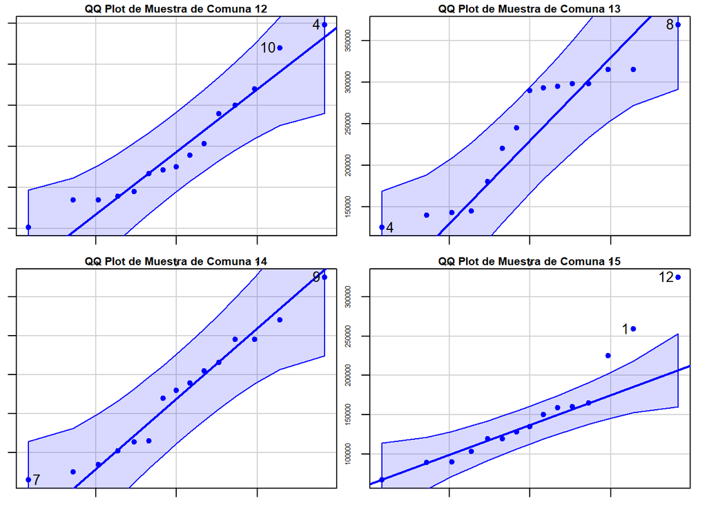

```
## [1] 12  1
```

```r
qqPlot(muestra_comuna4,
       main = "QQ Plot de Muestra de Comuna 15",
       xlab = "Cuantiles Teóricos",
       ylab = "Cuantiles Muestra",
       col = "blue",
       pch = 19,
       grid = TRUE)
```

- Dado que se estable un nivel de significancia del 5%, No se rechaza la hipótesis nula de normalidad. Hay evidencia suficiente que los datos siguen una distribución normal. *Se cumple el supuesto.*

### 6.2.2 Homocedasticidad

- Se realizan el test de Levene para analizar la homogenidad varianzas.

### Hipótesis sobre las Varianzas Poblacionales

La hipótesis nula (H0) de la prueba de Levene es que las varianzas son iguales en todos los grupos que se comparan. En contraste, la hipótesis alternativa (H1) sugiere que al menos una de las varianzas difiere de las otras.

$$\begin{aligned}&\text{Hipótesis Nula (H0)}: \sigma^2_1 = \sigma^2_2
= \cdots = \sigma^2_k \\&\text{Hipótesis Alternativa (H1)}: \text{Al
menos una varianza es diferente}\end{aligned}$$

```r
# test de Levene
leveneTest(value ~ group, data = data)
```

|  | Df | F value | Pr(>F) |
| --- | --- | --- | --- |
| group | 3 | 0.3655868 | 0.7780955 |
|  | 56 | NA | NA |

- El test de Levene arroja un p-valor de 0.7781, que es mayor al nivel de significancia establecido (α), por lo cual no se rechaza la hipótesis nula de que las varianzas son homogéneas. *Se cumple el supuesto de homogeneidad de varianzas.*

### 6.2.2 Independencia de las observaciones

- Viene determinada principalmente por el diseño del estudio. Seleccionar muestras de forma aleatoria es una estrategia que permite que las observaciones sean independientes entre sí.
- Con los supuestos validados se procede a realizar ANOVA, y en caso de ser necesario Tukey.

## 6.3 ANOVA y Tukey

### **Hipótesis para Análisis de Varianza (ANOVA)**

**Hipótesis Nula (H0):** Todas las medias poblacionales son iguales.
$$\
H_0: \mu_1 = \mu_2 = \mu_3 = \mu_4
\$$
**Hipótesis Alternativa (H1):** Al menos una media poblacional es diferente de las demás.
$$\
H_1: \text{Al menos una } \mu_i \text{ es distinta de las otras}
\$$

**Nivel de Significación**

Se utilizará un nivel de significancia de $\alpha = 0.05$.

```r
anova <- aov(data$value ~ data$group)
summary(anova)
```

```
##             Df    Sum Sq   Mean Sq F value Pr(>F)
## data$group   3 6.999e+10 2.333e+10   4.141 0.0101 *
## Residuals   56 3.155e+11 5.634e+09
## ---
## Signif. codes:  0 '***' 0.001 '**' 0.01 '*' 0.05 '.' 0.1 ' ' 1
```

```r
shapiro.test(residuals(anova)) #Chequeo de normalidad de residuos
```

```
##
##  Shapiro-Wilk normality test
##
## data:  residuals(anova)
## W = 0.96542, p-value = 0.08689
```

- Se rechaza la hipótesis nula del ANOVA, al menos un par de medias difiere entre sí. Para identificar específicamente cuáles medias difieren, se procederá a realizar el test de Tukey.

```r
#tukey
tukey_result <- TukeyHSD(anova)
tukey_result
```

```
##   Tukey multiple comparisons of means
##     95% family-wise confidence level
##
## Fit: aov(formula = data$value ~ data$group)
##
## $`data$group`
##                          diff        lwr        upr     p adj
## comuna 13-comuna 12  45512.67  -27060.01 118085.339 0.3539786
## comuna 14-comuna 12  24179.33  -48393.34  96752.005 0.8140560
## comuna 15-comuna 12 -46327.33 -118900.01  26245.339 0.3383603
## comuna 14-comuna 13 -21333.33  -93906.01  51239.339 0.8639206
## comuna 15-comuna 13 -91840.00 -164412.67 -19267.328 0.0076812
## comuna 15-comuna 14 -70506.67 -143079.34   2066.005 0.0598480
```

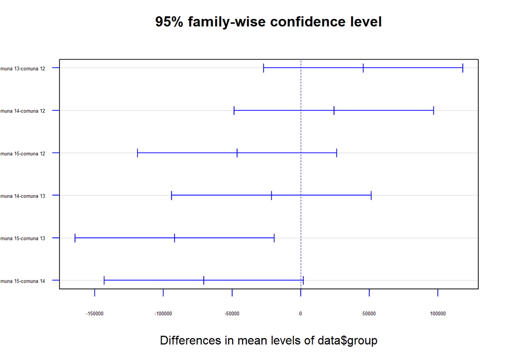

```r
# Plot
plot(tukey_result, las = 1, cex.axis = 0.4, col = "blue")
```

- El precio medio de los PH de la comuna 13 (Colegiales, Belgrano y Nuñez) difiere significativamente con respecto al precio medio de la comuna 15 (Chacarita, Paternal, Villa Crespo, Villa Ortuzar, Agronomia). Por otro lado, no se encontraron diferencias significativas entre las demás comunas.

# 7. Regresión Lineal Simple

Realice el análisis de regresión lineal simple tomando como variable explicada el precio de la propiedad. Elija otra variable a su criterio como explicativa. Tome los barrios que considere con valores similares en la variable explicada. Teniendo en cuenta la cantidad de datos seleccione una muestra aleatoria de tamaño grande 𝑛 > 30. Separe el conjunto de datos en entrenamiento (80%) y prueba (20%). Verifique los supuestos necesarios. Presente un informe analizando el reporte.

## 7.1 Análisis Exploratorio de Datos

- El análisis de datos se realiza para determinar que barrios voy a analizar.

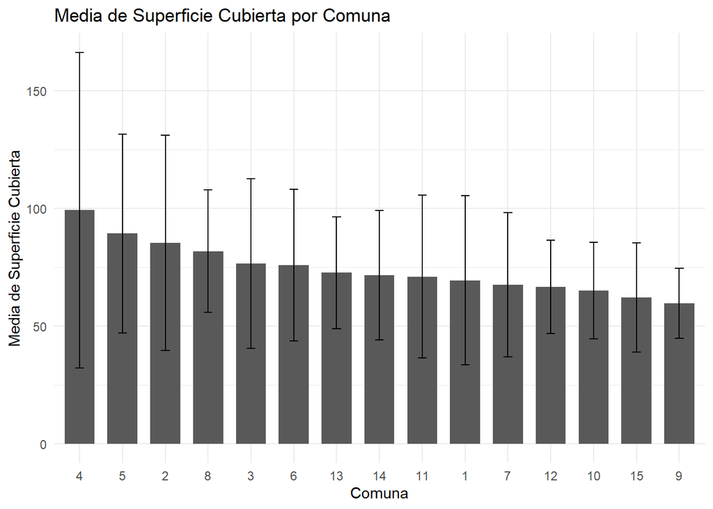

```r
# Crear el gráfico de barras
ggplot(resumen_por_comuna, aes(x = reorder(comuna1, -surface_covered_mean), y = surface_covered_mean)) +
  geom_bar(stat = "identity", width = 0.7) +  # valores basados en 'mean_surface'
  geom_errorbar(aes(ymin = surface_covered_mean - surface_covered_sd, ymax = surface_covered_mean + surface_covered_sd), width = 0.2) +
  labs(title = "Media de Superficie Cubierta por Comuna",
       x = "Comuna",
       y = "Media de Superficie Cubierta") +
  theme_minimal()
```

```r
    # Rotar etiquetas de x para mejor lectura
```

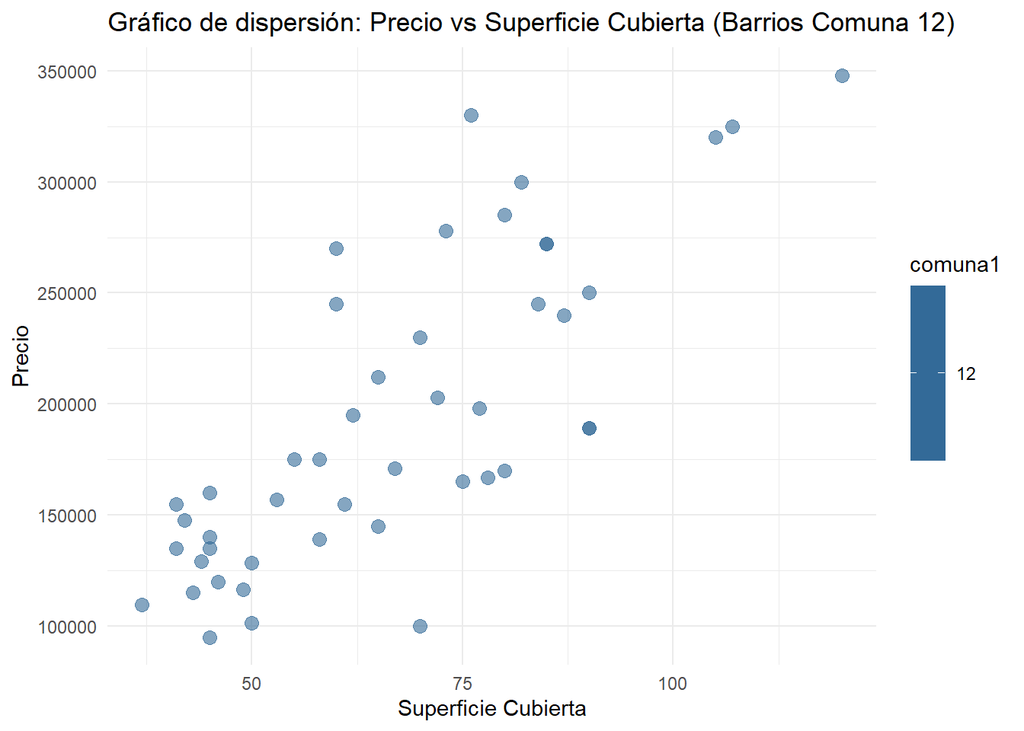

```r
# Filtrar los datos para mostrar solo los barrios de la comuna 12
df_comuna12 <- df %>% filter(comuna1 == 12)

# Crear el gráfico de dispersión para la comuna 12
ggplot(data = df_comuna12, aes(x = surface_covered, y = price, color = comuna1)) +
  geom_point(alpha = 0.6, size = 3) +
  labs(title = "Gráfico de dispersión: Precio vs Superficie Cubierta (Barrios Comuna 12)",
       x = "Superficie Cubierta",
       y = "Precio") +
  theme_minimal()
```

```r
# Filtrar las comunas con media y desvio similar
comuna_interes <- 12
df_xy <- df_comuna12
```

```r
set.seed(214)
#setear la semilla

df_rs <- df_xy %>% select(c('l3','price','surface_covered'))

# Dividir los datos en conjuntos de entrenamiento y prueba
df_split <- initial_split(df_rs,prop = 0.8)#para conservar la proporción de las clases

# Crear los conjuntos de entrenamiento y prueba
df_train <- df_split %>%training()
df_test <- df_split %>%testing()

# Número de datos en test y train
paste0("Total del dataset de entrenamiento: ", nrow(df_train))
```

```
## [1] "Total del dataset de entrenamiento: 36"
```

```r
paste0("Total del dataset de testeo: ", nrow(df_test))
```

```
## [1] "Total del dataset de testeo: 10"
```

## Modelo Estadístico

$$\LARGE Y_{i}= \beta_{0} + \beta_{1} X_1 + \varepsilon_i$$

Donde:

- $Y_i$ es el precio promedio para la superficie $i$

- $\beta_0$ es la ordenada al origen o intercepto

- $\beta_1$ es el coeficiente de la variable independiente $X_1$ , cuanto aumenta el precio cada aumento unitario de superficie cubierta.

- $X_1$ es la variable independiente , en este caso “superficie cubierta”

- $\varepsilon_i$ es el término de error

- Se corre el modelo y así se obtienen los residuales para el análisis de los supuestos, si los supuesto se cumplen luego se concluye sobre el modelo.

```r
modelo1<-lm(`price` ~ `surface_covered`,data=df_train)
```

## 7.2 Supuestos

- Calculamos residuales y predichos para analizar homogenidad de varianzas y normalidad.

```r
#Calculamos los residuos y los predichos
e<-resid(modelo1) # residuos
re<-rstandard(modelo1) #residuos estandarizados
pre<-predict(modelo1) #predichos
res<-cbind(df$`surface_covered`,df$`price`,pre,e,round(re,2))
#head(res)
```

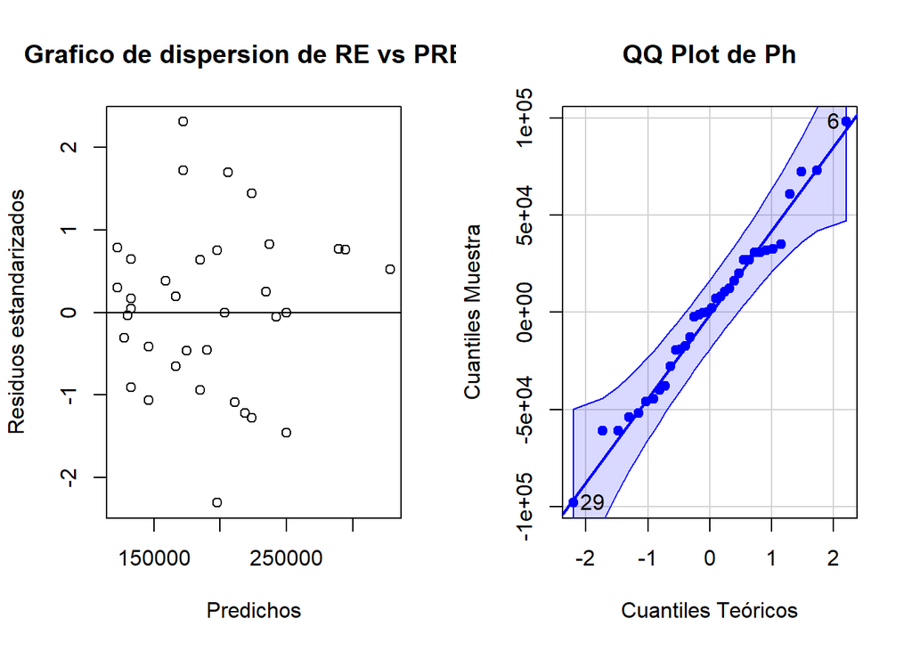

```
## [1] 29  6
```

```r
#Supuestos
par(mfrow = c(1, 2))
plot(pre, re, xlab="Predichos", ylab="Residuos estandarizados",main="Grafico de dispersion de RE vs PRED" )
abline(0,0)
qqPlot(e,main = "QQ Plot de Ph",
       xlab = "Cuantiles Teóricos",
       ylab = "Cuantiles Muestra",
       col = "blue",
       pch = 19,
       grid = TRUE)
```

```r
shapiro.test(e)
```

```
##
##  Shapiro-Wilk normality test
##
## data:  e
## W = 0.98509, p-value = 0.8987
```

- No se observa un patrón en el gráfico de dispersión de residuos vs. valores predichos, por lo que se puede asumir *homogeneidad en las varianzas*. Por otro lado, el test de Shapiro-Wilks arroja un p-valor mayor al nivel de significancia establecido, por lo cual no se rechaza la hipótesis nula. *Esto indica que los datos siguen una distribución normal*.

## 7.3. Análisis de modelo

- Dado que se cumplen los supuestos procedo analizar la regresión.

```r
summary(modelo1)
```

```
##
## Call:
## lm(formula = price ~ surface_covered, data = df_train)
##
## Residuals:
##    Min     1Q Median     3Q    Max
## -98014 -30339    990  27951  98002
##
## Coefficients:
##                 Estimate Std. Error t value Pr(>|t|)
## (Intercept)      15898.2    25539.6   0.622    0.538
## surface_covered   2601.7      359.5   7.237 2.24e-08 ***
## ---
## Signif. codes:  0 '***' 0.001 '**' 0.01 '*' 0.05 '.' 0.1 ' ' 1
##
## Residual standard error: 43180 on 34 degrees of freedom
## Multiple R-squared:  0.6064, Adjusted R-squared:  0.5948
## F-statistic: 52.38 on 1 and 34 DF,  p-value: 2.241e-08
```

Se observa una relación lineal significativa entre la superficie cubierta y el precio (p-valor < alfa). Además, el 60,64% de la variabilidad del precio puede ser explicada por la superficie cubierta.

## 7.4 Evaluamos el Modelo

```r
pred_m1 <- modelo1 |>
           predict(df_test) |>
            bind_cols(df_test)
pred_m1
```

| ...1 | l3 | price | surface_covered |
| --- | --- | --- | --- |
| 125167.9 | VILLA URQUIZA | 147500 | 42 |
| 135574.6 | COGHLAN | 120000 | 46 |
| 177201.1 | VILLA URQUIZA | 195000 | 62 |
| 229234.4 | COGHLAN | 299900 | 82 |
| 112159.6 | VILLA URQUIZA | 109500 | 37 |
| 153786.2 | VILLA URQUIZA | 157000 | 53 |
| 237039.3 | VILLA URQUIZA | 272000 | 85 |
| 213624.4 | SAAVEDRA | 330000 | 76 |
| 143379.6 | VILLA URQUIZA | 116500 | 49 |
| 216226.1 | VILLA URQUIZA | 198000 | 77 |

Cálculo del RMSE ( *Root Mean Squared Error* o Error Cuadrático Medio)

```r
# Evaluamos en df_test

rmse_result <- pred_m1 %>%
  metrics(truth = "surface_covered", estimate = "...1") %>%
  filter(.metric == "rmse")

# Mostrar el resultado del RMSE
print(rmse_result)
```

```
## # A tibble: 1 × 3
##   .metric .estimator .estimate
##   <chr>   <chr>          <dbl>
## 1 rmse    standard     179759.
```

```r
glance(modelo1)
```

| r.squared | adj.r.squared | sigma | statistic | p.value | df | logLik | AIC | BIC | deviance | df.residual | nobs |
| --- | --- | --- | --- | --- | --- | --- | --- | --- | --- | --- | --- |
| 0.6063763 | 0.5947991 | 43175.62 | 52.37691 | 2.241269e-08 | 1 | -434.2821 | 874.5641 | 879.3147 | 63380561661 | 34 | 36 |

# 8. Análisis de Regresión múltiple

Realice el análisis de regresión múltiple tomando como variable explicada el precio de la propiedad. Elija dos o más variables a su criterio como explicativas. Tome los barrios que considere con valores similares en la variable explicada. Teniendo en cuenta la cantidad de datos seleccione una muestra aleatoria de tamaño grande 𝑛 > 30. Separe el conjunto de datos en entrenamiento (80%) y prueba (20%). Verifique los supuestos necesarios. Presente un informe analizando el reporte.

## 8.1 Analisis exploratorio de datos

- Con el objetivo de mejorar el modelo del punto 7, se analiza la correlación deotras variables explicatorias. Este análisis permite elegir variables que no esten correlacionada con la superficie cubierta, evitando multicolinealidad.

```r
set.seed(214)
#setear la semilla

df_rm<- df_xy %>% select(c('l3','price','surface_covered','rooms','bathrooms', 'bedrooms', 'surface_total'))

# Dividir los datos en conjuntos de entrenamiento y prueba
df_split <- initial_split(df_rm,prop = 0.8) #para conservar la proporción de las clases

# Crear los conjuntos de entrenamiento y prueba
df_train_rm <- df_split %>%training()
df_test_rm <- df_split %>%testing()

# Número de datos en test y train
paste0("Total del dataset de entrenamiento: ", nrow(df_train))
```

```
## [1] "Total del dataset de entrenamiento: 36"
```

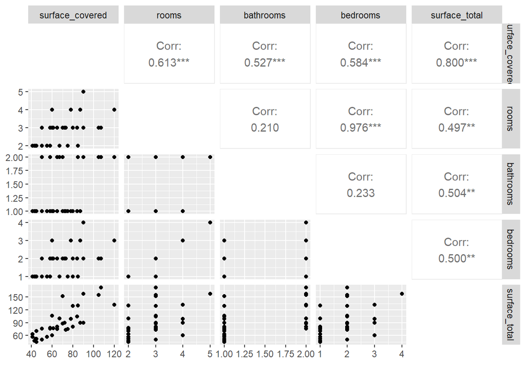

```r
ggpairs(df_train_rm,
        legend = 1,
        columns = 3:7, diag = list(continuous = "blankDiag"))+
  theme(legend.position = "bottom")
```

- Se agrega la variable bathrooms al modelo, ya que es la que esta menos correlacionada con la variable superficie cubierta.

## Modelo Estadístico

  $$\LARGE Y_{i}= \beta_{0} + \beta_{1} X_1
  + \beta_{2} X_2 +\varepsilon_i$$

  Donde:

  - $Y_i$ es el precio promedio para la superficie $i$

  - $\beta_0$ es la ordenada al origen o intercepto

  - $\beta_1$ es el coeficiente de la variable independiente $X_1$ , cuanto aumenta el precio cada aumento unitario de superficie cubierta.

  - $\beta_2$ es el coeficiente de la variable independiente $X_2$ , cuanto aumenta el precio cada aumento unitario de baño.

  - $X_1$ es la variable independiente , en este caso “superficie cubierta”
- - $X_2$ es la variable independiente , en este caso “baño”

  - $\varepsilon_i$ es el término de error

```r
modelo2<-lm(`price` ~ `surface_covered`+ `bathrooms`,
            data=df_train_rm)
```

## 8.2. Supuestos

Calculamos residuales y predichos para analizar homogenidad de varianzas y normalidad.

```r
#Calculamos los residuos y los predichos
e_m2<-resid(modelo2) # residuos
re_m2<-rstandard(modelo2) #residuos estandarizados
pre_m2<-predict(modelo2) #predichos
res_m2<-cbind(df$`surface_covered`, df$`lon`, df$`price`,pre_m2,e_m2,round(re_m2,2))
head(res_m2)
```

```
##                            pre_m2        e_m2
## [1,] 44 -34.57769  80000 185124.4 -40124.3755 -0.94
## [2,] 60 -34.60334 128000 145622.5 -44312.4763 -1.12
## [3,] 52 -34.60717 104000 219010.8 -52010.8331 -1.23
## [4,] 51 -34.60855 159000 328088.0  19911.9823  0.51
## [5,] 66 -34.60439 225000 249888.5    111.5001  0.00
## [6,] 85 -34.60018 240000 172091.1  97908.8775  2.28
```

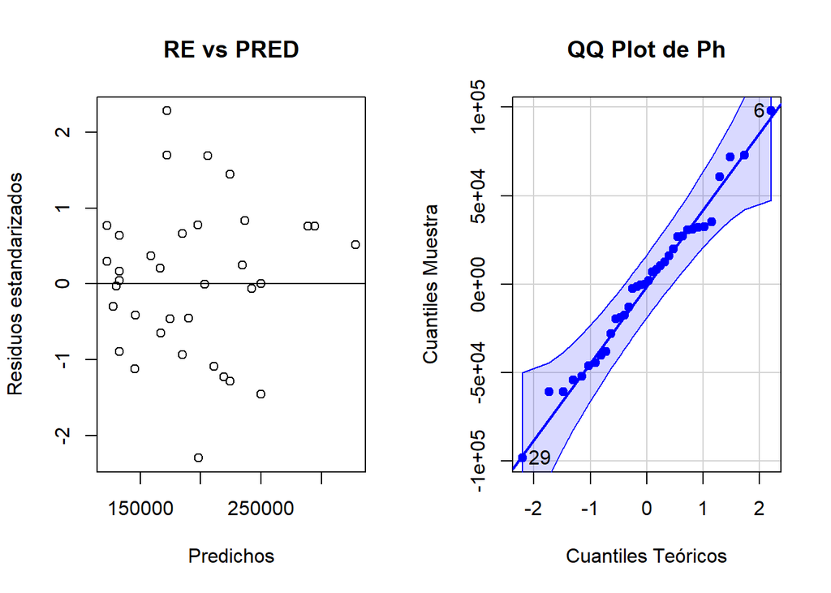

```
## [1] 29  6
```

```r
par(mfrow = c(1, 2))
plot(pre_m2, re_m2, xlab="Predichos", ylab="Residuos estandarizados",main="RE vs PRED" )
abline(0,0)
qqPlot(e_m2,main = "QQ Plot de Ph",
       xlab = "Cuantiles Teóricos",
       ylab = "Cuantiles Muestra",
       col = "blue",
       pch = 19,
       grid = TRUE)
```

```r
shapiro.test(resid(modelo2))
```

```
##
##  Shapiro-Wilk normality test
##
## data:  resid(modelo2)
## W = 0.98531, p-value = 0.9042
```

- No se observa un patrón en el gráfico de dispersion de residuos vs. predichos, por lo cual se puede asumir homegeneidad en las varizanas. Por otro lado el test de shapiro arroja un p-valor por mayor 0,05 por lo cual no se rechaza ho, asumiendo normalidad.

## 8.3 Análisis del modelo

- Dado que se cumplen los modelos se procede a analizar el modelo.

```r
summary(modelo2)
```

```
##
## Call:
## lm(formula = price ~ surface_covered + bathrooms, data = df_train_rm)
##
## Residuals:
##    Min     1Q Median     3Q    Max
## -98158 -30406   1060  28158  97909
##
## Coefficients:
##                 Estimate Std. Error t value Pr(>|t|)
## (Intercept)      16094.2    27404.3   0.587    0.561
## surface_covered   2606.7      429.3   6.072 7.82e-07 ***
## bathrooms         -402.1    18230.5  -0.022    0.983
## ---
## Signif. codes:  0 '***' 0.001 '**' 0.01 '*' 0.05 '.' 0.1 ' ' 1
##
## Residual standard error: 43820 on 33 degrees of freedom
## Multiple R-squared:  0.6064, Adjusted R-squared:  0.5825
## F-statistic: 25.42 on 2 and 33 DF,  p-value: 2.083e-07
```

```r
pred_rm <- modelo2 |>
           predict(df_test_rm) |>
           bind_cols(df_test_rm)
pred_rm
```

| ...1 | l3 | price | surface_covered | rooms | bathrooms | bedrooms | surface_total |
| --- | --- | --- | --- | --- | --- | --- | --- |
| 125171.4 | VILLA URQUIZA | 147500 | 42 | 2 | 1 | 1 | 65 |
| 135598.0 | COGHLAN | 120000 | 46 | 3 | 1 | 2 | 48 |
| 177304.4 | VILLA URQUIZA | 195000 | 62 | 3 | 1 | 2 | 79 |
| 229035.3 | COGHLAN | 299900 | 82 | 4 | 2 | 3 | 156 |
| 112138.2 | VILLA URQUIZA | 109500 | 37 | 2 | 1 | 1 | 40 |
| 153844.6 | VILLA URQUIZA | 157000 | 53 | 3 | 1 | 2 | 55 |
| 236855.2 | VILLA URQUIZA | 272000 | 85 | 2 | 2 | 1 | 130 |
| 213797.5 | SAAVEDRA | 330000 | 76 | 2 | 1 | 2 | 155 |
| 143418.0 | VILLA URQUIZA | 116500 | 49 | 2 | 1 | 1 | 68 |
| 216404.2 | VILLA URQUIZA | 198000 | 77 | 3 | 1 | 2 | 87 |

## 8.4 Evaluamos el Modelo

```r
rmse_result_rm <- pred_rm %>%
  metrics(truth = "price", estimate = "...1") %>%
  filter(.metric == "rmse")

print(rmse_result_rm)
```

```
## # A tibble: 1 × 3
##   .metric .estimator .estimate
##   <chr>   <chr>          <dbl>
## 1 rmse    standard      46792.
```

```r
glance(modelo2)
```

| r.squared | adj.r.squared | sigma | statistic | p.value | df | logLik | AIC | BIC | deviance | df.residual | nobs |
| --- | --- | --- | --- | --- | --- | --- | --- | --- | --- | --- | --- |
| 0.6063821 | 0.5825265 | 43824.59 | 25.41882 | 2.083219e-07 | 2 | -434.2818 | 876.5636 | 882.8977 | 63379627133 | 33 | 36 |

## 8.5 Importancia de las variables en el modelo

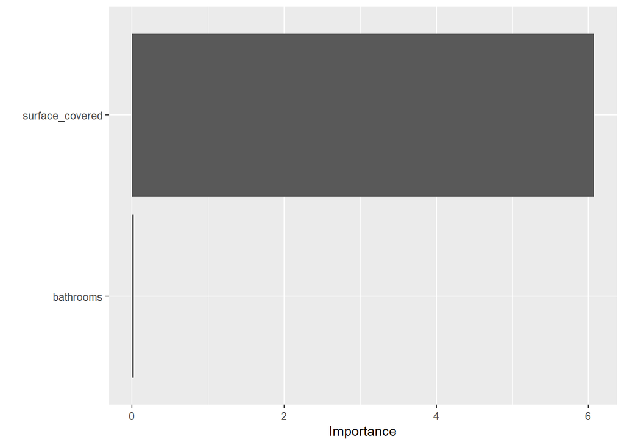

```r
importancia <- vip(modelo2)

plot(importancia)
```

# 9. Analisis discriminante linear (LDA)

Elija dos comunas para realizar el análisis discriminante (pueden ser las utilizadas en los puntos anteriores u otros). Codifique la variable comuna. Aplique el análisis discriminante. Interprete los resultados.

- Para este análisis, se utilizaron las comunas 12 y 11, considerando las variables de superficie cubierta, superficie total y precio. Debido a que estas variables no cumplen con el supuesto de multinormalidad, se decidió aplicar una transformación logarítmica.

```r
# Filtrar las comunas para hacer analisis discriminante
comunas_interes <- c(12, 11)
# Transformacion de variables
df$log_price <- log(df$price)
df$log_surface_total <- log(df$surface_total)
df$log_surface_covered<-log(df$surface_covered)
# Analisis con variables originales
df_ad <- df %>% select(surface_total,surface_covered, price,comuna1)%>%
  filter(comuna1 %in% comunas_interes) %>%
  mutate(comuna1 = factor(comuna1))
```

```r
set.seed(214)#setear la semilla

df_split <- initial_split(df_ad,
                          prop = 0.85,
                          strata = comuna1)#para conservar la proporción de las clases

df_train_ad <- df_split |>
              training() |>
              mutate(across(where(is.numeric), scale))

df_test_ad <- df_split |>
              testing()|>
              mutate(across(where(is.numeric), scale))

# Número de datos en test y train
paste0("Total del dataset de entrenamiento: ", nrow(df_train_ad))
```

```
## [1] "Total del dataset de entrenamiento: 67"
```

```r
paste0("Total del dataset de testeo: ", nrow(df_test_ad))
```

```
## [1] "Total del dataset de testeo: 12"
```

```r
comuna12<- subset(df_train_ad[,1:3], df_train_ad$comuna1 == 12)
comuna11<- subset(df_train_ad[,1:3], df_train_ad$comuna1 == 11)
```

## 9.2 Supuestos

### 9.2.1 Normalidad

```r
mvShapiro.Test(as.matrix(comuna12))
```

```
##
##  Generalized Shapiro-Wilk test for Multivariate Normality by
##  Villasenor-Alva and Gonzalez-Estrada
##
## data:  as.matrix(comuna12)
## MVW = 0.92747, p-value = 0.0003752
```

```r
mvShapiro.Test(as.matrix(comuna11))
```

```
##
##  Generalized Shapiro-Wilk test for Multivariate Normality by
##  Villasenor-Alva and Gonzalez-Estrada
##
## data:  as.matrix(comuna11)
## MVW = 0.92663, p-value = 0.006754
```

- Dado que no se cumple se procede a transformar las variables originales.

```r
# Filtrar las comunas para hacer analisis discriminante
comunas_interes <- c(12, 11)
# Transformacion de variables
df$log_price <- log(df$price)
df$log_surface_total <- log(df$surface_total)
df$log_surface_covered<-log(df$surface_covered)
# Analisis con variables transformadas
df_ad <- df %>% select(log_surface_total,log_surface_covered, log_price,comuna1)%>%
  filter(comuna1 %in% comunas_interes) %>%
  mutate(comuna1 = factor(comuna1))
```

```r
set.seed(214)#setear la semilla

df_split <- initial_split(df_ad,
                          prop = 0.85,
                          strata = comuna1)#para conservar la proporción de las clases

df_train_ad <- df_split |>
              training() |>
              mutate(across(where(is.numeric), scale))

df_test_ad <- df_split |>
              testing()|>
              mutate(across(where(is.numeric), scale))

# Número de datos en test y train
paste0("Total del dataset de entrenamiento: ", nrow(df_train_ad))
```

```
## [1] "Total del dataset de entrenamiento: 67"
```

```r
paste0("Total del dataset de testeo: ", nrow(df_test_ad))
```

```
## [1] "Total del dataset de testeo: 12"
```

```r
comuna12<- subset(df_train_ad[,1:3], df_train_ad$comuna1 == 12)
comuna11<- subset(df_train_ad[,1:3], df_train_ad$comuna1 == 11)
```

Vuelvo analizar Normalidad

```r
mvShapiro.Test(as.matrix(comuna12))
```

```
##
##  Generalized Shapiro-Wilk test for Multivariate Normality by
##  Villasenor-Alva and Gonzalez-Estrada
##
## data:  as.matrix(comuna12)
## MVW = 0.96275, p-value = 0.1505
```

```r
mvShapiro.Test(as.matrix(comuna11))
```

```
##
##  Generalized Shapiro-Wilk test for Multivariate Normality by
##  Villasenor-Alva and Gonzalez-Estrada
##
## data:  as.matrix(comuna11)
## MVW = 0.94608, p-value = 0.07877
```

- *Se cumple el supuesto normalidad* utilizando las variables transformadas, ya que en ambos test de Shapiro-Wilks no se rechaza Ho.

### 9.2.2 Independencia de las observaciones

Viene dada por el diseño.

### 9.2.3 Homocedasticidad

- Hipotesis (Ho): las matrices de varianzas-covarianzas de los grupos son iguales.

```r
# Realizar la prueba de Box's M
boxM_result <- boxM(df_train_ad[, 1:3], df_train_ad$comuna1)

# Ver los resultados
print(boxM_result)
```

```
##
##  Box's M-test for Homogeneity of Covariance Matrices
##
## data:  df_train_ad[, 1:3]
## Chi-Sq (approx.) = 11.587, df = 6, p-value = 0.07184
```

- Dado que el valor p es mayor al nivel de significancia. *Se cumple el supuesto homogeneidad de varianza.*

## 9.3 Analisis y Coeficientes de los discriminantes lineales:

```r
model_lda <- lda(comuna1~., data =df_train_ad)
model_lda
```

```
## Call:
## lda(comuna1 ~ ., data = df_train_ad)
##
## Prior probabilities of groups:
##        11        12
## 0.4179104 0.5820896
##
## Group means:
##    log_surface_total log_surface_covered  log_price
## 11         0.2170786          0.05777107 -0.2090562
## 12        -0.1558513         -0.04147666  0.1500916
##
## Coefficients of linear discriminants:
##                             LD1
## log_surface_total   -1.34767334
## log_surface_covered -0.06893485
## log_price            1.40122333
```

  **LD1=−1.34767334⋅log_surface_total−0.06893485⋅log_surface_covered+1.40122333⋅log_price**
- Las funciones discriminantes son combinaciones lineales (o ejes) que se construyen para separar los grupos basados en las variables predictoras. Se puede tener hasta tantas funciones discriminantes como grupos menos uno. En este caso, al tener dos grupos ( comuna=11 y comuna 12), se obtiene una única función discriminante que maximiza la separación entre ellos.

```r
prop = model_lda$svd^2/sum(model_lda$svd^2)
prop #varianza entre grupos explicada por cada FD
```

```
## [1] 1
```

- El valor de 1 que se obtiene para la proporción de varianza explicada por cada función discriminante (FD) en en LDA) indica que esta única función discriminante captura toda la diferencia o variabilidad entre tus dos grupos (`comuna1 = 11` y `comuna1 = 12`). Este resultado es esperado y válido cuando solo hay dos grupos en el análisis discriminante.

## 9.4 Predicción del modelo en df_test

```r
predictions <- model_lda |>
                predict(df_test_ad)
predictions
```

```
## $class
##  [1] 12 11 12 11 11 12 12 12 12 12 12 11
## Levels: 11 12
##
## $posterior
##           11        12
## 1  0.3598888 0.6401112
## 2  0.5161604 0.4838396
## 3  0.1574310 0.8425690
## 4  0.6646365 0.3353635
## 5  0.5341787 0.4658213
## 6  0.4318551 0.5681449
## 7  0.4002484 0.5997516
## 8  0.3066183 0.6933817
## 9  0.1448310 0.8551690
```

[output cut: 18 more lines]

## 9.5 Matriz de confusión

### 9.5.1 En df_train

```r
cm_lda<-table(predict(model_lda,type="class")$class,df_train_ad$comuna1)
```

```r
# Calcular la precisión
accuracy <- sum(diag(cm_lda)) / sum(cm_lda)
print(paste("Accuracy:", round(accuracy, 3)))
```

```
## [1] "Accuracy: 0.806"
```

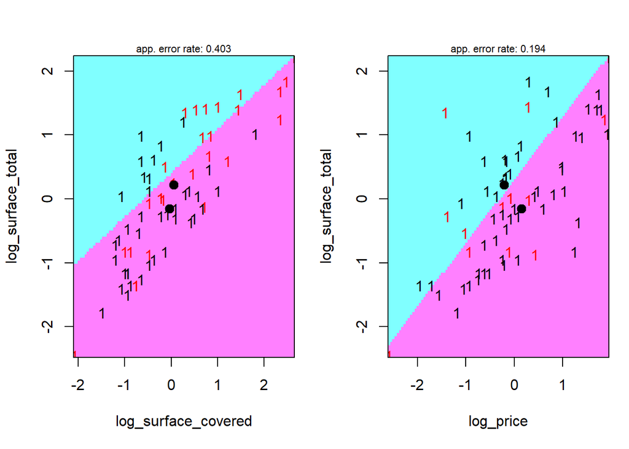

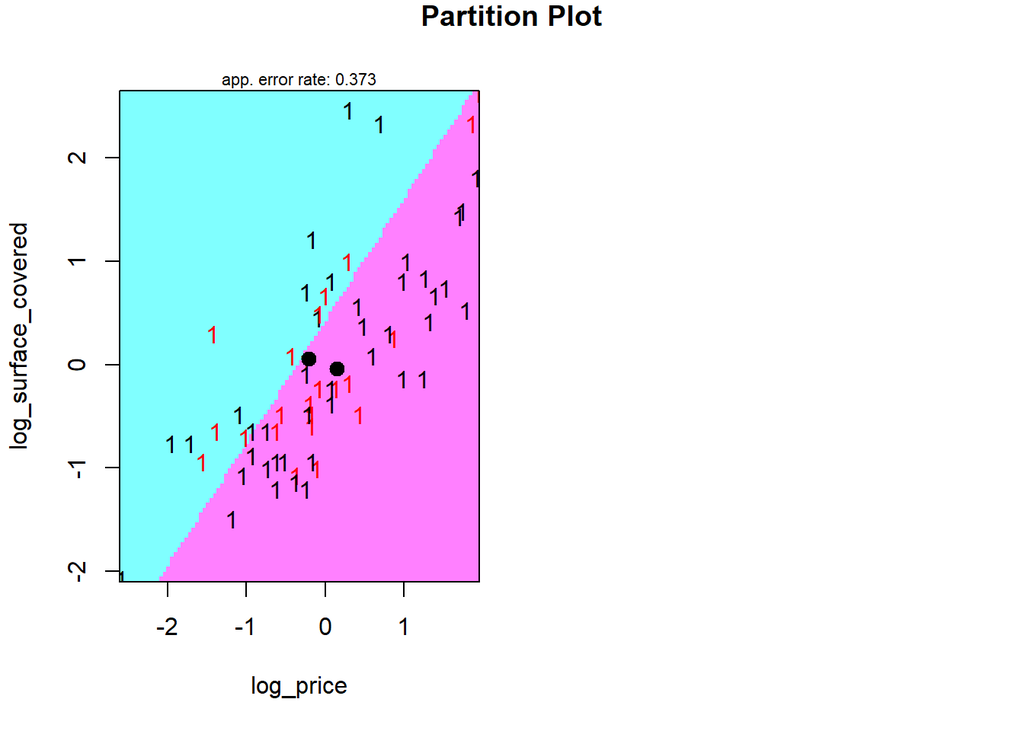

```r
partimat (comuna1~. , data=df_train_ad , method="lda")
```

### 9.5.2 En df_test

```r
lda.test <- predict(model_lda,df_test_ad)
df_test_ad$lda <- lda.test$class
cm_lda_t<-table(df_test_ad$lda,df_test_ad$comuna1)#matriz confusion test
cm_lda_t
```

```
##
##      11 12
##   11  2  2
##   12  3  5
```

```r
accuracy_lda_test <- sum(diag(cm_lda_t)) / sum(cm_lda_t)
print(paste("Accuracy:", round(accuracy_lda_test, 3)))
```

```
## [1] "Accuracy: 0.583"
```

# 10. Clasificación Supervisada

Aplique otro método de clasificación supervisada sobre los datos utilizados en el punto 9 y compare los resultados respecto a la metodología utilizada en el punto anterior.

## 10.1 K-Nearest Neighbors (KNN)

```r
# Convertir tibble a data.frame
df_train_knn <- as.data.frame(df_train_ad)
df_test_knn <-as.data.frame(df_test_ad[-5])
```

```r
# Defino modelo knn
set.seed(214)
task <- makeClassifTask(data = df_train_knn, target = "comuna1")
lrn_knn <- makeLearner("classif.knn", predict.type = "response",par.vals = list("k" = 2))
mod_knn <- mlr::train(lrn_knn, task)
```

```
## Functional features have been converted to numerics
```

```r
# Predicción TEST
pred_knn<- predict(mod_knn, newdata = df_test_knn)
pred_knn
```

```
## Prediction: 12 observations
## predict.type: response
## threshold:
## time: 0.02
##   truth response
## 1    11       12
## 2    12       11
## 3    12       11
## 4    11       11
## 5    12       11
## 6    11       12
## ... (#rows: 12, #cols: 2)
```

```r
acc_knn <- round(measureACC(as.data.frame(pred_knn)$truth, as.data.frame(pred_knn)$response),3)
acc_knn
```

```
## [1] 0.5
```

```r
# Obtener y visualizar la matriz de confusión
conf_matrix <- calculateConfusionMatrix(pred_knn)
print(conf_matrix)
```

```
##         predicted
## true     11 12 -err.-
##   11      2  3      3
##   12      3  4      3
##   -err.-  3  3      6
```

```r
# Predicción TRAIN (naive)
pred_knn1 = predict(mod_knn, newdata = df_train_knn) # por si quiero ver naive sobre training
acc_knn1 <- round(measureACC(as.data.frame(pred_knn1)$truth, as.data.frame(pred_knn1)$response),3)
pred_knn1
```

```
## Prediction: 67 observations
## predict.type: response
## threshold:
## time: 0.00
##   truth response
## 1    11       11
## 2    11       11
## 3    11       11
## 4    11       12
## 5    11       11
## 6    11       11
## ... (#rows: 67, #cols: 2)
```

```r
acc_knn1
```

```
## [1] 0.881
```

```r
# Cambio los k
acc=NULL
acc2=NULL
ks = seq(1,67,1)
for (i in 1:length(ks)) {
        lrn_knn = makeLearner("classif.knn", predict.type = "response",par.vals = list("k" = i))
        mod_knn = mlr::train(lrn_knn, task)
        pred_knn= predict(mod_knn, newdata = df_test_knn)
        acc[i] = measureACC(as.data.frame(pred_knn)$truth, as.data.frame(pred_knn)$response)
        pred_knn_ = predict(mod_knn, newdata = df_train_knn) # por si quiero ver naive sobre training
        acc2[i] = measureACC(as.data.frame(pred_knn_)$truth, as.data.frame(pred_knn_)$response)

}
```

[output not shown]

[output cut: 12 more lines]

[output not shown]

```r
par(mfcol = c(1,2))

new_df1 <- as.data.frame(cbind(ks,acc))
new_df1 <- new_df1%>%mutate(sub_data='test')
new_df2 <- as.data.frame(cbind(ks,acc2))
colnames(new_df2) <- c('ks','acc')
new_df2 <- new_df2%>%mutate(sub_data='train')

new_df <- as.data.frame(rbind(new_df1,new_df2))
new_df1[which.max(new_df1$acc),"ks"]
```

```
## [1] 5
```

```r
new_df2[which.max(new_df2$acc),"ks"]
```

```
## [1] 1
```

```r
# Encontrar el mejor valor de 'k' y 'threshold'
best_k_test <- new_df1[which.max(new_df1$acc), "ks"]
best_k_train <- new_df2[which.max(new_df2$acc), "ks"]

print(paste("Mejor k_test:", best_k_test))
```

```
## [1] "Mejor k_test: 5"
```

```r
print(paste("Mejor K_train:", best_k_train))
```

```
## [1] "Mejor K_train: 1"
```

[output not shown]

```r
# Métricas del modelo de knn
Métrica <- c('valor','datos')
Accuracy <- c(acc_knn,'prueba')
Accuracy. <- c(acc_knn1,'entrenamiento')
# Imprimo resultados de métricas de performance
kable(rbind(Métrica, Accuracy, Accuracy.))
```

| Métrica | valor | datos |
| --- | --- | --- |
| Accuracy | 0.5 | prueba |
| Accuracy. | 0.881 | entrenamiento |

[output not shown]

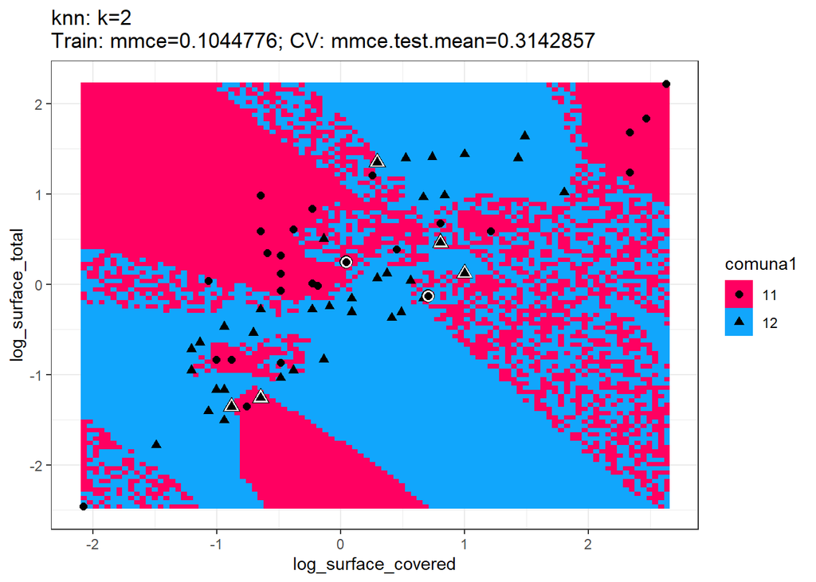

```r
lrn_knn = makeLearner("classif.knn", predict.type = "response",par.vals = list("k" = 2))
plotLearnerPrediction(lrn_knn,task,features = c("log_surface_covered", "log_surface_total"),cv=100L,gridsize=100)+scale_fill_manual(values=c("#ff0061","#11a6fc"))+theme_bw()
```

- Al comparar estos métodos de clasificación, observamos que los resultados de accuracy son similares. Para el conjunto de datos de prueba, el LDA obtuvo un accuracy de 0.583, mientras que KNN alcanzó 0.5. En cuanto al conjunto de entrenamiento, LDA mostró un accuracy de 0.806 frente al 0.881 de KNN.
- Aunque ambos métodos muestran resultados de precisión comparables, es importante considerar otros aspectos además del accuracy. Por ejemplo, el KNN parece desempeñarse ligeramente mejor en el conjunto de entrenamiento, mientras que el LDA lo hace mejor en el conjunto de prueba. Además, factores como la interpretación de las predicciones, la eficiencia computacional y la facilidad de ajuste de hiperparámetros también pueden influir en la elección del método más adecuado para un problema específico